# MLE resolve heteroscedasticity

Taotao

10/25/2020

Here is a typical heteroscedasticity problem. Try to resolve the problem with maximum likelihood estimation.

we have three parameters to estimate. For data generation, we have $\beta_0 = 1$, $\beta_1 = 3$, $k = 0.2$. We have 13 data here.

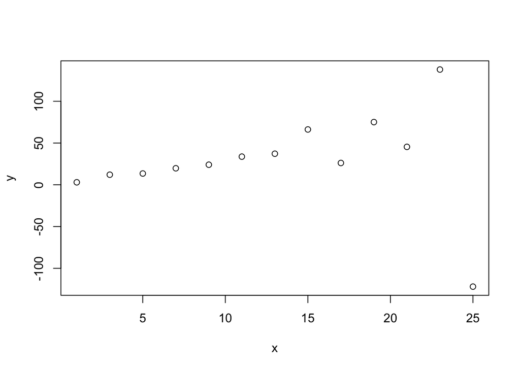

```r
# create x value
x = seq(1,26,by = 2)

# variance has exponential relationship with the x
var = exp(0.2 * x)

# generate y with rnorm
y = c()
for (i in 1:length(x)){
  y[i] = rnorm(n = 1, mean = 3 * x[i] + 1, sd = var[i])
}

# plot the x, y
plot(x, y)
```

The goal here is to build a model which includes the uncertainty (variance). We use maximum likelihood estimation to build the model. Need to estimate three parameters

For a single data, the log likelihood is $l(\beta_1, \beta_2, k|y) = log[\frac{e^{-\frac{(x - \beta_0 - \beta_1x)^2}{2 \sigma^2}}}{\sqrt{2 \pi e^{2kx}}}] = -\frac{log(2 \pi)}{2} - \frac{kx}{2} - \frac{(y - \beta_0 - \beta_1x)^2}{2 e^{kx}}$

Therefore, we simply need to add all the log likelihood to get the total log likelihood. So, we will have $l(\beta_1, \beta_2, k|y_1, y_2...) = -\sum_{i = 1}^n (\frac{log(2 \pi)}{2} + \frac{kx_i}{2} + \frac{(y_i - \beta_0 - \beta_1x_i)^2}{2 e^{kx_i}})$

There is a nice function to calculate the minimum value of any functions, called optim. We first take the negative of log likelihood function, then plug in all 13 data, and get a function with three independent variables b0, b1, and k. Optim can help us find the parameters.

```r
ll <- function(z){
  b0 = z[1]
  b1 = z[2]
  k = z[3]

  return(    log(2*pi)/2   +    k*x[1]/2   +    (y[1] - b0- b1*x[1])^2 /(2*exp(k*x[1])) +
             log(2*pi)/2   +    k*x[2]/2   +    (y[2] - b0- b1*x[2])^2 /(2*exp(k*x[2])) +
             log(2*pi)/2   +    k*x[3]/2   +    (y[3] - b0- b1*x[3])^2 /(2*exp(k*x[3])) +
             log(2*pi)/2   +    k*x[4]/2   +    (y[4] - b0- b1*x[4])^2 /(2*exp(k*x[4])) +
             log(2*pi)/2   +    k*x[5]/2   +    (y[5] - b0- b1*x[5])^2 /(2*exp(k*x[5])) +
             log(2*pi)/2   +    k*x[6]/2   +    (y[6] - b0- b1*x[6])^2 /(2*exp(k*x[6])) +
             log(2*pi)/2   +    k*x[7]/2   +    (y[7] - b0- b1*x[7])^2 /(2*exp(k*x[7])) +
             log(2*pi)/2   +    k*x[8]/2   +    (y[8] - b0- b1*x[8])^2 /(2*exp(k*x[8])) +
             log(2*pi)/2   +    k*x[9]/2   +    (y[9] - b0- b1*x[9])^2 /(2*exp(k*x[9])) +
             log(2*pi)/2   +    k*x[10]/2   +    (y[10] - b0- b1*x[10])^2 /(2*exp(k*x[10])) +
             log(2*pi)/2   +    k*x[11]/2   +    (y[11] - b0- b1*x[11])^2 /(2*exp(k*x[11])) +
             log(2*pi)/2   +    k*x[12]/2   +    (y[12] - b0- b1*x[12])^2 /(2*exp(k*x[12])) +
             log(2*pi)/2   +    k*x[13]/2   +    (y[13] - b0- b1*x[13])^2 /(2*exp(k*x[13]))

               )

}
```

```r
# the optimal/estimated parameters: b0_hat, b1_hat, k_hat
optim(c(1,1,1), ll)$par
```

```
## [1] 0.7985697 2.8843434 0.3738103
```

```r
# the minimal log likelihood
optim(c(1,1,1), ll)$value
```

```
## [1] 48.97451
```